# The Laser Weapon System

In the last few lessons, we focussed on the projectile weapon system.

In this lesson, we’ll implement the laser weapon system with its AI controller.

The laser fires for a determined amount of time, unlike the projectile weapon that fires immediately.

Now that we know how the controller-targeting system works, we can implement both at once in one lesson.

Here’s a preview of what we’ll build.

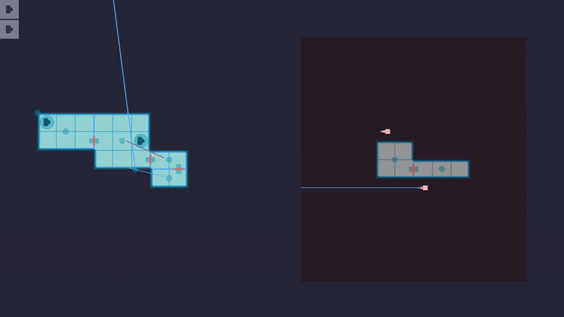

As always, I tinted the AI viewport, so it’s easy to distinguish. I also turned on *Debug -> Visible Collision Shapes* to see the invisible parts as well.

In the opposing viewport, we have a sweeping animation. You can see how the laser controller updates the sweeping path every time it fires.

## The laser weapon scene

We can build on top of the *WeaponProjectile* scene from the previous lessons.

Open a new scene file by going to *Scene -> New Inherited Scene…* and pick `res://TacticalSpaceCombat/Ship/Weapons/WeaponProjectile.tscn` as the base scene.

Extend the tree with a

[figure not shown]

`Timer` and a

[figure not shown]

`Line2D`:

[figure not shown]

Change the *Weapon* node *Region -> Rect* property to pick the laser weapon sprite from the atlas:

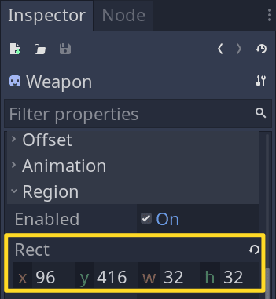

For the

[figure not shown]

`Timer` node, set the *WaitTime* to `0.6` and turn on *One Shot* in the *Inspector*.

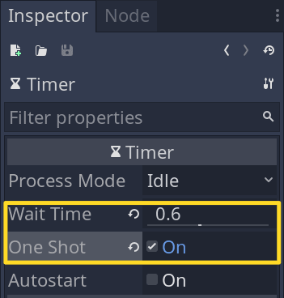

We use the

[figure not shown]

`Timer` to determine for how long the laser weapon keeps firing.

Set the following properties on

[figure not shown]

`Line2D`:

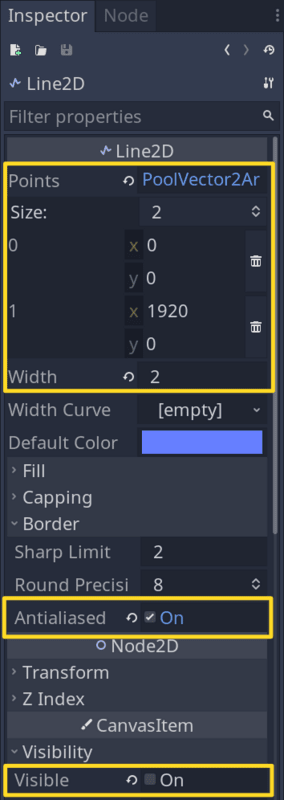

We want the laser line to cover the entire screen and stretch horizontally to match the sprite orientation.

With

[figure not shown]

`Line2D` visible, you should get this result:

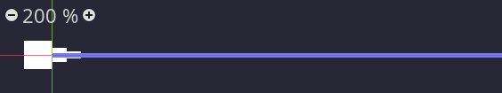

The laser line should be as wide as the screen viewport.

If you finished playing with

[figure not shown]

`Line2D`, remember to set its *Visible* property to false and save the scene file at `res://TacticalSpaceCombat/Ship/Weapons/WeaponLaser.tscn`.

## The laser weapon script

Since we inherit from the *WeaponProjectile* scene, the root node comes with a script already attached. Remove that script first, and then add a new script called `WeaponLaser.gd`.

This can be saved in the same directory as *WeaponProjectile*.

Start by replacing

[figure not shown]

`Sprite` with our custom *Weapon* class:

```
tool
class_name WeaponLaser
extends Weapon
```

Continue with the signals:

```
## Like in `WeaponProjectile`'s case, we need to send some parameters to the
## other viewport. We do this when `fire_started` gets emitted.
signal fire_started(params)
signal fire_stopped
```

We have a basic horizontal line representing the laser in this scene. But on the opposing viewport, we’ll have a sweeping animation. For that animation to know when to start and stop, we use the signals defined above.

Declare these variables:

```
## We add a customizable `targeting_length` variable for the sweeping laser
## length to vary the reach of the weapon.
export (int, 0, 250) var targeting_length := 140

## We can have different laser colors.
export var color := Color("b0305c")

## This gets updated by the controller so that the weapon knows if it acquired a
## target or not.
var has_targeted := false

onready var timer: Timer = $Timer
onready var line: Line2D = $Line2D
```

In the ready function we define the signal connections:

```
func _ready() -> void:
    if Engine.editor_hint:
        return

    # When the `Timer` times out it means the weapon finished firing so we can
    # start a new cycle.
    timer.connect("timeout", self, "emit_signal", ["fire_stopped"])
    timer.connect("timeout", self, "set_is_charging", [true])

    # We also directly connect to `Line2D.set_visible()`. This skips having to
    # deal with conditions in `set_is_charging()`.
    timer.connect("timeout", line, "set_visible", [false])

    line.default_color = color
```

Let’s add the warning message handler:

```
func _get_configuration_warning() -> String:
    var parent := get_parent()
    var is_verified := parent != null and parent is ControllerAILaser
    return "" if is_verified else "WeaponLaser needs to be a parent of ControllerAILaser"
```

*ControllerAILaser* Will be defined in the next section to clear up that undeclared error.

Now for the `fire()` function:

```
func fire() -> void:
    if not can_fire():
        return

    timer.start()
    has_targeted = false
    line.visible = true
    var params := {"duration": timer.wait_time}
    emit_signal("fire_started", params)


func can_fire() -> bool:
    return not is_charging and has_targeted
```

And that concludes coding the laser weapon.

## The AI laser controller

The AI laser controller scene, is as simple as the projectile version - all in one

[figure not shown]

`Node2D` node.

Create a new scene with a

[figure not shown]

`Node2D` root node and save it at `res://TacticalSpaceCombat/Ship/Weapons/ControllerAILaser.tscn`.

Attach a script to the node with the following content, building on top of the *Controller* class:

```
tool
class_name ControllerAILaser
extends Controller


func _ready() -> void:
    if Engine.editor_hint:
        return

    # This is the exact approach we took in `ControllerAIProjectile`'s case
    # except this time we send the `weapon.targeting_length` information. This
    # length is used to generate the sweeping line in the other viewport.
    var msg := {"targeting_length": weapon.targeting_length}
    weapon.connect("fire_stopped", self, "emit_signal", ["targeting", msg])

    yield(get_tree(), "idle_frame")
    emit_signal("targeting", msg)
```

That’s all there is to the *ControllerAILaser* code. Everything else is automated using the

[figure not shown]

`Tween` node and the *Controller* parent class.

We need to pass this extra information when emitting the signals to get the process started.

### Accounting for the laser in the parent Controller class

Open `res://TacticalSpaceCombat/Ship/Weapons/Controller.gd` and make the following change:

```
- enum Type {PROJECTILE}
+ enum Type {PROJECTILE, LASER}
```

We need to handle this new type of laser in `_on_Ship_targeted()`:

```
func _on_Ship_targeted(msg: Dictionary) -> void:
    # match msg:
        # ...
        {"type": Type.LASER, "success": true}:
            weapon.has_targeted = true
```

After **successfully** acquiring a new target, we update `weapon.has_targeted` to reflect the new state.

*Note* that we depend on the dictionary having a `success` key set to `true`. This will become relevant when dealing with the player controller-weapons system.

As we saw above, we use this information in the `weapon.can_fire()` function.

## Generating the sweeping laser line

Whenever the laser weapon finishes firing, we generate two random positions from different rooms defining the sweeping laser segment.

This process is best implemented in the *Rooms* node because we need access to all *Room* positions.

But first, we have to add a couple of utility functions to generate a position within the room randomly.

### The vector utility functions

We start with `res://TacticalSpaceCombat/Utils.gd` by adding a function that generates a random

[figure not shown]

`Vector2` within a perimeter defined by two points:

```
## Returns a random `Vector2` within the perimeter defined by `top_left` and
## `bottom_right`.
static func randvf_range(_rng: RandomNumberGenerator, top_left: Vector2, bottom_right: Vector2) -> Vector2:
    var x := _rng.randf_range(top_left.x, bottom_right.x)
    var y := _rng.randf_range(top_left.y, bottom_right.y)
    return Vector2(x, y)
```

I named the function `randvf_range()` to be similar to the built-in variants from the `RandomNumberGenerator` class. The `v` comes from vector, and `f` stands for `float` the type.

We now use this utility function in the *Room* script to get a random position within the room’s perimeter. Open `res://TacticalSpaceCombat/Ship/Rooms/Room.gd` and first define the random generator:

```
var _rng := RandomNumberGenerator.new()
```

Update `_ready()` to initialize the `RandomNumberGenerator`:

```
func _ready() -> void:
    # ...
    # connect("area_entered", self, "_on_area_entered")
    _rng.randomize()
```

We now add this utility function:

```
## Returns a random `Vector2` in the `Room` perimeter in world coordinates.
func randv() -> Vector2:
    var top_left_world := _tilemap.map_to_world(_top_left)
    var bottom_right_world := _tilemap.map_to_world(_bottom_right)
    return Utils.randvf_range(_rng, top_left_world, bottom_right_world)
```

### The laser sweeping line generator

We can now use the utility functions defined above to generate two points between two different rooms randomly. This will become the sweeping laser path.

Go back to the *Rooms* script and add the following function:

```
## Returns an array of the form `[point1, point2]` defining a segment for
## sweeping the laser across two random rooms.
func get_laser_points(targeting_length: float) -> Array:
    # Get a random room index.
    var room_index_first := _rng.randi_range(0, _rooms_count - 1)

    # Create an array with the remaining room indices skipping
    # `room_index_first`.
    var remaining := []
    for room_index in range(_rooms_count):
        if room_index != room_index_first:
            remaining.push_back(room_index)

    # Pick a random index from the array for the second room.
    var index = _rng.randi_range(0, remaining.size() - 1)
    var room_index_second = remaining[index]

    # Get two random positions in the two rooms.
    var point1: Vector2 = get_child(room_index_first).randv()
    var point2: Vector2 = get_child(room_index_second).randv()

    # Update `point2` to be `targeting_length` distance away from `point1` in
    # the same direction.
    point2 = point1.move_toward(point2, targeting_length)
    return [point1, point2]
```

Now that we implemented the line generator, we can use it to animate the beam moving across two rooms.

For this, we need to create a new scene that functions as the sweeping laser.

## The laser tracker scene

Create a new scene file with

[figure not shown]

`Node2D` as root. Rename the root node to *LaserTracker* and add the following tree structure:

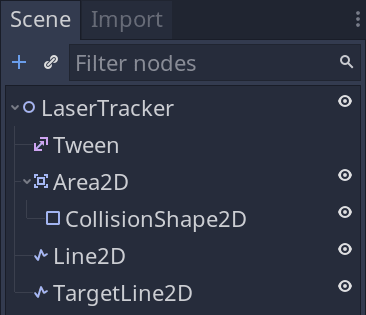

Start by turning off *Monitorable* on

[figure not shown]

`Area2D`.

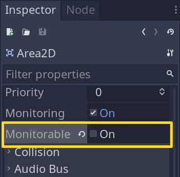

We don’t want the laser to interact with the rooms unless it’s in the sweeping motion.

It’s helpful to have

[figure not shown]

`Area2D` in a group to filter this type of laser-room interaction from code. Add

[figure not shown]

`Area2D` to the `laser` group.

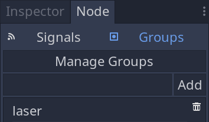

Assign a

[figure not shown]

`CircleShape2D` to the

[figure not shown]

`CollisionShape2D`’s `Shape` property. The default values are acceptable.

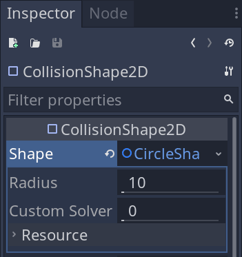

For

[figure not shown]

`Line2D`, we match the parameters from the *WeaponLaser* scene. The difference here is that we don’t bother changing the *Points* because we animate this line from code.

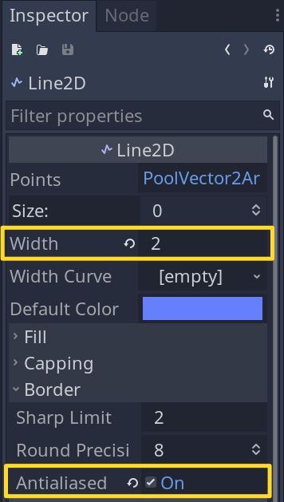

We use the same settings for *TargetLine2D*, except I didn’t bother turning on *Border -> Antialiased*. It gives it a jagged look, making it stand out a bit.

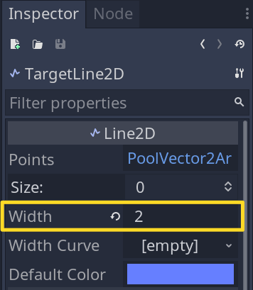

## Coding the laser tracker

The *LaserTracker* script is a bit more advanced, but we’ll go over it bit by bit.

The scene itself has two purposes:

1. It takes care of the sweeping laser animation when the opposing ship fires.
2. While sweeping the

[figure not shown]

   `Line2D`, we also animate the

[figure not shown]

   `Area2D` node, which allows us to check for collisions with rooms.

```
extends Node2D

signal targeted(msg)
```

We send the weapon type back in the signal to distinguish it in the `Controller._on_Ship_targeted()` function.

Let’s move on to the variables:

```
## These are the default values for `Line2D` and `TargetLine2D` nodes. We start
## with invalid default positions so that they don't render anything while not
## firing.

## We use a `PoolVector2Array` for two reasons:

## 1. It's copied on assignment, unlike `Array`. For example
##    `line.points = LINE_DEFAULT` creates a new copy of the `PoolVector2Array`
##    meaning we don't have to worry about changing the values stored in
##    `LINE_DEFAULT` by accident.
## 2. `Line2D.points` property is itself a `PoolVector2Array`, so `LINE_DEFAULT`
##     can be assigned directly without any problems.
const LINE_DEFAULT := PoolVector2Array([Vector2.INF, Vector2.INF])

## These are the positions of the `TargetLine2D` node - the sweeping path.
var _target_points := LINE_DEFAULT

var _rng := RandomNumberGenerator.new()
var _rooms: Node2D = null
```

Next we have the usual node references:

```
onready var tween: Tween = $Tween
onready var area: Area2D = $Area2D
onready var line: Line2D = $Line2D
onready var target_line: Line2D = $TargetLine2D
```

We start the functions with `setup()` and `_ready()`:

```
func setup(color: Color, rooms: Node2D) -> void:
    _rooms = rooms
    line.default_color = color
    target_line.default_color = color


func _ready() -> void:
    _rng.randomize()
    target_line.points = LINE_DEFAULT
    line.points = LINE_DEFAULT
```

Moving to the signal handlers, we start with `_on_Controller_targeting()`:

```
func _on_Controller_targeting(msg: Dictionary) -> void:
    # Update `TargetLine2D` with a randomly generated line from
    # `Rooms.get_laser_points()`.
    target_line.points = _rooms.get_laser_points(msg.targeting_length)

    emit_signal("targeted", {"type": Controller.Type.LASER, "success": true})
```

We finish up with the handlers for `fire_started` and `fire_stopped` signals, along with a helper function for the sweeping animation:

```
func _on_Weapon_fire_started(params: Dictionary) -> void:
    # Remember we initialized `target_line.points` with `LINE_DEFAULT` in the
    # `_ready()` function. So we first check if the target is valid.
    if Vector2.INF in target_line.points:
        return

    # Generate an off-screen position for the first `Line2D` point - the
    # incoming laser origin. We animate the second index with a helper function
    # and the `Tween` node.
    line.points[0] = _rooms.mean_position + Utils.randvf_circle(_rng, Projectile.MAX_DISTANCE)

    # We use `Tween.interpolate_method()` to "animate" the `_swipe_laser()`
    # helper function. The function gets an input going from
    # `target_line.poisnts[0]` to `target_line.points[1]`.
    tween.interpolate_method(
        self, "_swipe_laser", target_line.points[0], target_line.points[1], params.duration
    )
    tween.start()


func _on_Weapon_fire_stopped() -> void:
    tween.remove_all()
    line.points = LINE_DEFAULT
    area.position = Vector2.ZERO
    # We don't care to reset `target_line.points` here because each new cycle
    # it'll be updated to random positions anyway.


## Helper function to animate one end of `Line2D` - the end that swipes over the
## ship rooms.

## We need a function for this because we're interested in animating
## `Line2D.points[1]` and we can't do it with `Tween.interpolate_property()`
## function.
func _swipe_laser(offset: Vector2) -> void:
    line.points[1] = offset
    # We also move the position of `Area2D` to match the tip of the laser
    # strike.
    area.position = line.points[1]
```

This concludes coding the *LaserTracker* script.

We can now move on to updating the *ShipTemplate* script. We need a helper function that adds a *LaserTracker* node to the scene tree because we generate them from code depending on how many weapons we attach to the ship.

## Coding the laser tracker helper functions

Open the *ShipTemplate* scene. We first need to add a new *Lasers* group node to the scene to accommodate for the dynamic *LaserTracker* nodes:

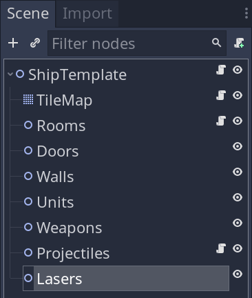

Now we can move to code it. Open the *ShipTemplate* script and add the following constant at the top:

```
## We instantiate this from code, depending on how many laser weapons the
## opponent ship has. We do this in TacticalSpaceCombat, but the helper function
## is in ShipTemplate.
const LaserTracker := preload("Weapons/LaserTracker.tscn")
```

Add the new *Lasers* reference variable:

```
onready var lasers: Node2D = $Lasers
```

And finally, the helper `add_laser_tracker()` function:

```
func add_laser_tracker(color: Color) -> Node:
    var laser_tracker := LaserTracker.instance()
    lasers.add_child(laser_tracker)
    laser_tracker.setup(color, rooms)
    return laser_tracker
```

We’re now ready to finish connecting the signals in the *TacticalSpaceCombat* script.

## Connecting the signals

Open the *TacticalSpaceCombat* script, we are adding a second branch to the `_ready_weapons_ai()` if statement to account for *ControllerAILaser* as well:

```
func _ready_weapons_ai() -> void:
    # for controller in ship_ai.weapons.get_children():
        # ...
        elif controller is ControllerAILaser:
            # We add a `LaserTracker` node to the player ship for every
            # `ControllerAILaser` in `ShipAI`.
            var laser_tracker: Node = ship_player.add_laser_tracker(controller.weapon.color)
            controller.connect(
                "targeting", laser_tracker, "_on_Controller_targeting", [], CONNECT_DEFERRED
            )
            controller.weapon.connect("fire_started", laser_tracker, "_on_Weapon_fire_started")
            controller.weapon.connect("fire_stopped", laser_tracker, "_on_Weapon_fire_stopped")
            laser_tracker.connect("targeted", controller, "_on_Ship_targeted")
```

Due to the order in which Godot handles node signal emissions we defer the `targeting` `ControllerAILaser` signal to the next idle frame with `CONNECT_DEFERRED`.

We do this to emit `targeting` **after** `WeaponLaser`’s `fire_stopped` signal, otherwise the targeting will fail.

Now we’re ready to test the work so far.

## Testing the AI laser weapon

At this point, I invite you to customize the AI ship with two laser weapons for testing it out.

Open the *ShipAI* scene file and add two *ControllerAILaser* nodes with a *WeaponLaser* child each. Note that the *WeaponLaser* is still called *Weapon*, as per our design.

Also, *ShipAI* is updated to reflect the changes from *ShipTemplate*, including the *Lasers* node.

[figure not shown]

Customize the parameters on the *Weapon* nodes as you see fit.

I left the default values on `ControllerAILaser/Weapon` and used the following values on `ControllerAILaser2/Weapon`.

- *Charge Time*: `1`
- *Targeting Length*: `100`
- *Color*: `#4da6ff`

*Note* that the export variables are on the weapon nodes, not the controllers.

I ended up with this design:

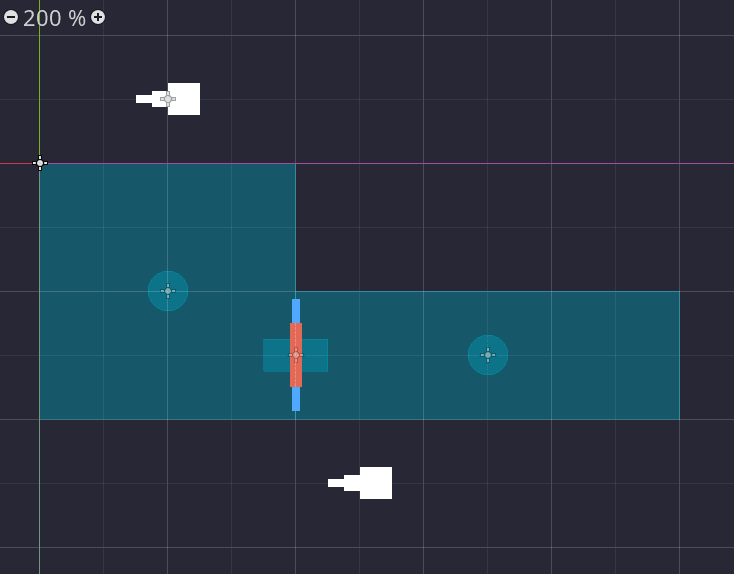

If you now run the game you should get a similar behavior to the intro video:

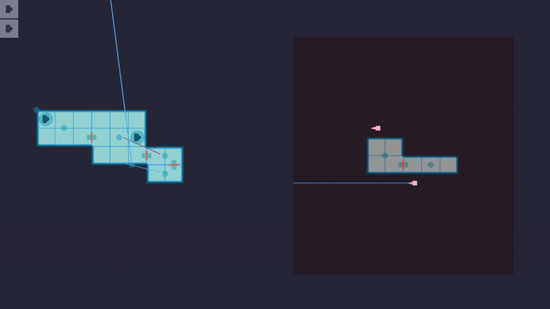

## Conclusion

In this lesson, we completed the *ControllerAILaser* - *WeaponLaser* system implementation.

We used the knowledge gained from working on the *ControllerAIProjectile* - *WeaponProjectile* system to speed up the process.

We saw how to implement a completely different weapon type by building on top of the foundations from our previous lessons: the base *Weapon* class and the *WeaponProjectile* scene file.

We saw how to add the *LaserTracker* node dynamically in one part of the scene tree, based on the structure from a different part of the demo.

And we finally saw how to use `Tween.interpolate_method()` to animate a node property that we can’t handle with the `Tween.interpolate_property()` function.

In the next lesson, we’ll go over the UI requirments for the player *Controller* - *Weapon* system.

## Code reference

`res://TacticalSpaceCombat/Ship/Weapons/WeaponLaser.gd`:

```
tool
class_name WeaponLaser
extends Weapon

signal fire_started(params)
signal fire_stopped

export (int, 0, 250) var targeting_length := 140
export var color := Color("b0305c")

var has_targeted := false

onready var timer: Timer = $Timer
onready var line: Line2D = $Line2D


func _ready() -> void:
    if Engine.editor_hint:
        return

    timer.connect("timeout", self, "emit_signal", ["fire_stopped"])
    timer.connect("timeout", self, "set_is_charging", [true])
    timer.connect("timeout", line, "set_visible", [false])
    line.default_color = color


func _get_configuration_warning() -> String:
    var parent := get_parent()
    var is_verified := parent != null and parent is ControllerAILaser
    return "" if is_verified else "WeaponLaser needs to be a parent of ControllerAILaser"


func fire() -> void:
    if not can_fire():
        return

    timer.start()
    has_targeted = false
    line.visible = true
    var params := {"duration": timer.wait_time}
    emit_signal("fire_started", params)


func can_fire() -> bool:
    return not is_charging and has_targeted
```

`res://TacticalSpaceCombat/Ship/Weapons/ControllerAILaser.gd`:

```
tool
class_name ControllerAILaser
extends Controller


func _ready() -> void:
    if Engine.editor_hint:
        return

    var msg := {"targeting_length": weapon.targeting_length}
    weapon.connect("fire_stopped", self, "emit_signal", ["targeting", msg])

    yield(get_tree(), "idle_frame")
    emit_signal("targeting", msg)
```

`res://TacticalSpaceCombat/Ship/Weapons/Controller.gd`:

```
class_name Controller
extends Node2D

signal targeting(msg)

enum Type {PROJECTILE, LASER}

onready var weapon: Weapon = $Weapon


func _on_Ship_targeted(msg: Dictionary) -> void:
    match msg:
        {"type": Type.PROJECTILE, ..}:
            if msg.index == get_index():
                weapon.target_position = msg.target_position
        {"type": Type.LASER, "success": true}:
            weapon.has_targeted = true


func _get_configuration_warning() -> String:
    return "" if has_node("Weapon") else "%s needs a Weapon child" % name
```

`res://TacticalSpaceCombat/Utils.gd`:

```
class_name Utils

const DIRECTIONS := [
    Vector2.UP,
    Vector2.RIGHT + Vector2.UP,
    Vector2.RIGHT,
    Vector2.RIGHT + Vector2.DOWN,
    Vector2.DOWN,
    Vector2.LEFT + Vector2.DOWN,
    Vector2.LEFT,
    Vector2.LEFT + Vector2.UP
]

static func xy_to_index(width: int, offset: Vector2) -> int:
    return int(offset.x + width * offset.y)

static func index_to_xy(width: int, index: int) -> Vector2:
    return Vector2(index % width, index / width)

static func erase_value(dict: Dictionary, value) -> bool:
    var out := false
    for key in dict:
        if dict[key] == value:
            out = dict.erase(key)
    return out

static func randvf_circle(_rng: RandomNumberGenerator, radius: float) -> Vector2:
    return (radius * Vector2.RIGHT).rotated(_rng.randf_range(0, TAU))

static func randvf_range(_rng: RandomNumberGenerator, top_left: Vector2, bottom_right: Vector2) -> Vector2:
    var x := _rng.randf_range(top_left.x, bottom_right.x)
    var y := _rng.randf_range(top_left.y, bottom_right.y)
    return Vector2(x, y)
```

`res://TacticalSpaceCombat/Ship/Rooms/Room.gd`:

```
tool
class_name Room
extends Area2D

export var size := Vector2.ONE setget set_size

var _rng := RandomNumberGenerator.new()

var _entrances := {}

var _area := 0
var _top_left := Vector2.ZERO
var _bottom_right := Vector2.ZERO

var _iter_index := 0

var _tilemap: TileMap = null

onready var collision_shape: CollisionShape2D = $CollisionShape2D
onready var feedback: NinePatchRect = $Feedback


func setup(tilemap: TileMap) -> void:
    _tilemap = tilemap
    _setup_extents()

    _area = size.x * size.y
    _top_left = _tilemap.world_to_map(position - collision_shape.shape.extents)
    _bottom_right = _top_left + size

    feedback.rect_position -= collision_shape.shape.extents
    feedback.rect_size = 2 * collision_shape.shape.extents


func _setup_extents() -> void:
    if _tilemap != null:
        collision_shape.shape.extents = 0.5 * _tilemap.map_to_world(size)


func _ready() -> void:
    connect("mouse_entered", self, "_on_mouse_entered_exited", [true])
    connect("mouse_exited", self, "_on_mouse_entered_exited", [false])
    connect("area_entered", self, "_on_area_entered")
    _rng.randomize()


func _on_mouse_entered_exited(has_entered: bool) -> void:
    feedback.visible = has_entered
    var group := "selected-room"
    if has_entered:
        add_to_group(group)
    elif is_in_group(group):
        remove_from_group(group)


func _on_area_entered(area: Area2D) -> void:
    if area.is_in_group("door"):
        var entrance := position - area.position
        entrance = entrance.project(Vector2.DOWN.rotated(area.rotation)).normalized()
        entrance *= 0.5 * _tilemap.cell_size.x
        entrance += area.position
        entrance = _tilemap.world_to_map(entrance)
        _entrances[entrance] = null


func randv() -> Vector2:
    var top_left_world := _tilemap.map_to_world(_top_left)
    var bottom_right_world := _tilemap.map_to_world(_bottom_right)
    return Utils.randvf_range(_rng, top_left_world, bottom_right_world)


func has_point(point: Vector2) -> bool:
    return Rect2(_top_left, size).has_point(point)


func set_size(value: Vector2) -> void:
    for axis in [Vector2.AXIS_X, Vector2.AXIS_Y]:
        size[axis] = max(1, value[axis])
    _setup_extents()


func get_slot(slots: Dictionary, unit: Unit) -> Vector2:
    var out := Vector2.INF
    var entrance := _get_entrance(_tilemap.world_to_map(unit.path_follow.position))

    var valid_positions := []
    for offset in self:
        valid_positions.push_back([offset, offset.distance_to(entrance)])
    valid_positions.sort_custom(self, "sort_by_second_index")

    for data in valid_positions:
        var offset: Vector2 = data[0]
        if not (offset in slots and slots[offset] != unit):
            out = offset
            break
    return out


static func sort_by_second_index(a: Array, b: Array) -> bool:
    return a[1] < b[1]


func _get_entrance(from: Vector2) -> Vector2:
    var out := Vector2.INF
    var distance := INF
    for entrance in _entrances:
        var curve: Curve2D = _tilemap.find_path(from, entrance)
        var length := curve.get_baked_length()
        if distance > length:
            distance = length
            out = entrance
    return out


func _iter_init(_arg) -> bool:
    _iter_index = 0
    return _iter_is_running()


func _iter_next(_arg) -> bool:
    _iter_index += 1
    return _iter_is_running()


func _iter_get(_arg) -> Vector2:
    var offset := Utils.index_to_xy(size.x, _iter_index)
    return _top_left + offset


func _iter_is_running() -> bool:
    return _iter_index < _area
```

`res://TacticalSpaceCombat/Ship/Rooms.gd`:

```
extends Node2D

signal targeted(msg)

var mean_position := Vector2.INF

var _rng := RandomNumberGenerator.new()
var _rooms_count := 0


func _ready() -> void:
    _rng.randomize()
    _rooms_count = get_child_count()
    mean_position = _get_mean_position()


func _on_Controller_targeting(msg: Dictionary) -> void:
    var r := _rng.randi_range(0, _rooms_count - 1)
    var room: Room = get_child(r)
    msg.type = Controller.Type.PROJECTILE
    msg.target_position = room.position
    emit_signal("targeted", msg)


func get_laser_points(targeting_length: float) -> Array:
    var room_index_first := _rng.randi_range(0, _rooms_count - 1)
    var remaining := []
    for room_index in range(_rooms_count):
        if room_index != room_index_first:
            remaining.push_back(room_index)
    var index = _rng.randi_range(0, remaining.size() - 1)
    var room_index_second = remaining[index]

    var point1: Vector2 = get_child(room_index_first).randv()
    var point2: Vector2 = get_child(room_index_second).randv()
    point2 = point1.move_toward(point2, targeting_length)
    return [point1, point2]


func _get_mean_position() -> Vector2:
    var out := Vector2.ZERO
    for room in get_children():
        out += room.position

    if _rooms_count > 0:
        out /= _rooms_count
    return out
```

`res://TacticalSpaceCombat/Ship/Weapons/LaserTracker.gd`:

```
extends Node2D

signal targeted(msg)

const LINE_DEFAULT := PoolVector2Array([Vector2.INF, Vector2.INF])

var _rng := RandomNumberGenerator.new()
var _rooms: Node2D = null

onready var tween: Tween = $Tween
onready var area: Area2D = $Area2D
onready var line: Line2D = $Line2D
onready var target_line: Line2D = $TargetLine2D


func setup(color: Color, rooms: Node2D) -> void:
    _rooms = rooms
    line.default_color = color
    target_line.default_color = color


func _ready() -> void:
    _rng.randomize()
    target_line.points = LINE_DEFAULT
    line.points = LINE_DEFAULT


func _on_Controller_targeting(msg: Dictionary) -> void:
    target_line.points = _rooms.get_laser_points(msg.targeting_length)
    emit_signal("targeted", {"type": Controller.Type.LASER})


func _on_Weapon_fire_started(params: Dictionary) -> void:
    if Vector2.INF in target_line.points:
        return

    line.points[0] = _rooms.mean_position + Utils.randvf_circle(_rng, Projectile.MAX_DISTANCE)
    tween.interpolate_method(
        self, "_swipe_laser", target_line.points[0], target_line.points[1], params.duration
    )
    tween.start()


func _on_Weapon_fire_stopped() -> void:
    tween.remove_all()
    line.points = LINE_DEFAULT
    area.position = Vector2.ZERO


func _swipe_laser(offset: Vector2) -> void:
    line.points[1] = offset
    area.position = line.points[1]
```

`res://TacticalSpaceCombat/Ship/ShipTemplate.gd`:

```
tool
extends Node2D

const LaserTracker := preload("Weapons/LaserTracker.tscn")

var _slots := {}

onready var tilemap: TileMap = $TileMap
onready var rooms: Node2D = $Rooms
onready var doors: Node2D = $Doors
onready var units: Node2D = $Units
onready var weapons: Node2D = $Weapons
onready var projectiles: Node2D = $Projectiles
onready var lasers: Node2D = $Lasers


func _ready() -> void:
    call("_ready_editor_hint" if Engine.editor_hint else "_ready_not_editor_hint")


func _ready_editor_hint() -> void:
    for room in rooms.get_children():
        room.setup(tilemap)


func _ready_not_editor_hint() -> void:
    for unit in units.get_children():
        for door in doors.get_children():
            door.connect("opened", unit, "set_is_walking", [true])

        var position_map := tilemap.world_to_map(unit.path_follow.position)
        _slots[position_map] = unit

    for room in rooms.get_children():
        room.setup(tilemap)
        for point in room:
            tilemap.set_cellv(point, 0)
    tilemap.setup(rooms, doors)
    projectiles.setup(rooms.mean_position)


func _unhandled_input(event: InputEvent) -> void:
    if not event.is_action_pressed("right_click"):
        return

    for unit in get_tree().get_nodes_in_group("selected-unit"):
        var point1: Vector2 = tilemap.world_to_map(unit.path_follow.position)
        for room in get_tree().get_nodes_in_group("selected-room"):
            if not room.owner.is_in_group("player"):
                break

            var point2: Vector2 = room.get_slot(_slots, unit)
            if is_inf(point2.x):
                break

            var path: Curve2D = tilemap.find_path(point1, point2)
            Utils.erase_value(_slots, unit)
            _slots[point2] = unit
            unit.walk(path)


func add_laser_tracker(color: Color) -> Node:
    var laser_tracker := LaserTracker.instance()
    lasers.add_child(laser_tracker)
    laser_tracker.setup(color, rooms)
    return laser_tracker
```

`res://TacticalSpaceCombat.gd`:

```
extends Node2D

const UIUnit = preload("TacticalSpaceCombat/UI/UIUnit.tscn")

onready var ship_player: Node2D = $ShipPlayer
onready var ship_ai: Node2D = $ViewportContainer/Viewport/ShipAI
onready var ui_units: VBoxContainer = $UI/Units


func _ready() -> void:
    _ready_units()
    _ready_weapons_ai()


func _ready_units() -> void:
    for unit in ship_player.units.get_children():
        var ui_unit: ColorRect = UIUnit.instance()
        ui_units.add_child(ui_unit)
        unit.setup(ui_unit)


func _ready_weapons_ai() -> void:
    for controller in ship_ai.weapons.get_children():
        if controller is ControllerAIProjectile:
            controller.connect("targeting", ship_player.rooms, "_on_Controller_targeting")
            controller.weapon.connect(
                "projectile_exited", ship_player.projectiles, "_on_Weapon_projectile_exited"
            )
            ship_player.rooms.connect("targeted", controller, "_on_Ship_targeted")
        elif controller is ControllerAILaser:
            var laser_tracker: Node = ship_player.add_laser_tracker(controller.weapon.color)
            controller.connect(
                "targeting", laser_tracker, "_on_Controller_targeting", [], CONNECT_DEFERRED
            )
            controller.weapon.connect("fire_started", laser_tracker, "_on_Weapon_fire_started")
            controller.weapon.connect("fire_stopped", laser_tracker, "_on_Weapon_fire_stopped")
            laser_tracker.connect("targeted", controller, "_on_Ship_targeted")
```